# Practical Machine Learning Week 4 Project

Stavros Oikonomou

29/5/2020

### Background

Using devices such as Jawbone Up, Nike FuelBand, and Fitbit it is now possible to collect a large amount of data about personal activity relatively inexpensively. These type of devices are part of the quantified self movement ??? a group of enthusiasts who take measurements about themselves regularly to improve their health, to find patterns in their behavior, or because they are tech geeks. One thing that people regularly do is quantify how much of a particular activity they do, but they rarely quantify how well they do it. In this project, your goal will be to use data from accelerometers on the belt, forearm, arm, and dumbell of 6 participants. They were asked to perform barbell lifts correctly and incorrectly in 5 different ways. More information is available from the website here: http://groupware.les.inf.puc-rio.br/har (see the section on the Weight Lifting Exercise Dataset).

### Data

The training data for this project are available here:

https://d396qusza40orc.cloudfront.net/predmachlearn/pml-training.csv

The test data are available here:

https://d396qusza40orc.cloudfront.net/predmachlearn/pml-testing.csv

The data for this project come from this source: http://groupware.les.inf.puc-rio.br/har. If you use the document you create for this class for any purpose please cite them as they have been very generous in allowing their data to be used for this kind of assignment.

#### Loading the libraries

```r
library(caret)
```

#### downloading the datasets

```r
download.file("https://d396qusza40orc.cloudfront.net/predmachlearn/pml-training.csv", destfile="./pml-training.csv")
download.file("https://d396qusza40orc.cloudfront.net/predmachlearn/pml-testing.csv", destfile="./pml-testing.csv")
```

#### Loading the datasets

```r
train <- read.csv("pml-training.csv", na.strings = c("NA","","#DIV/0!"))
test <- read.csv("pml-testing.csv", na.strings = c("NA","","#DIV/0!"))
```

### Data Preprocessing

#### Removing the columns with NA’s

```r
train <- train[,colSums(is.na(train)) == 0]
test <- test[,colSums(is.na(test)) == 0]
```

#### Removing near to zero variance columns

```r
var <- nearZeroVar(train)
train <- train[,-var]
test <- test[,-var]
```

```r
dim(train)
```

```
## [1] 19622    59
```

```r
dim(test)
```

```
## [1] 20 59
```

#### Removing the non-predictors from the training set. This columns do not help us at predictions

```r
train<- train[,-c(1:7)]
test <- test[,-c(1:7)]
```

#### Splitting the train set and create a training set and a validation set

```r
inTrain <- createDataPartition(train$classe, p = 0.6, list = FALSE)
training<- train[inTrain,]
validation<- train[-inTrain,]
```

```r
dim(training)
```

```
## [1] 11776    52
```

```r
dim(validation)
```

```
## [1] 7846   52
```

### Decision Tree Model

```r
dt_model <- train(classe~., method="rpart",data=training)
dt_pred_valid <- predict(dt_model,validation)
confusionMatrix(dt_pred_valid,validation$classe)
```

```
## Confusion Matrix and Statistics
##
##           Reference
## Prediction    A    B    C    D    E
##          A 2027  639  629  594  350
##          B   38  515   39  220  256
##          C  125  311  547  160  347
##          D   39   53  153  312   61
##          E    3    0    0    0  428
##
## Overall Statistics
##
##                Accuracy : 0.488
##                  95% CI : (0.4769, 0.4991)
##     No Information Rate : 0.2845
##     P-Value [Acc > NIR] : < 2.2e-16
##
##                   Kappa : 0.3297
##
##  Mcnemar's Test P-Value : < 2.2e-16
##
## Statistics by Class:
##
##                      Class: A Class: B Class: C Class: D Class: E
## Sensitivity            0.9082  0.33926  0.39985  0.24261  0.29681
## Specificity            0.6060  0.91261  0.85443  0.95335  0.99953
## Pos Pred Value         0.4782  0.48221  0.36711  0.50485  0.99304
## Neg Pred Value         0.9432  0.85202  0.87083  0.86525  0.86325
## Prevalence             0.2845  0.19347  0.17436  0.16391  0.18379
## Detection Rate         0.2583  0.06564  0.06972  0.03977  0.05455
## Detection Prevalence   0.5403  0.13612  0.18991  0.07877  0.05493
## Balanced Accuracy      0.7571  0.62594  0.62714  0.59798  0.64817
```

### Random Forest

```r
rf_model <- train(classe ~., method='rf', data=training, ntree=20)
rf_pred_valid <- predict(rf_model, validation)
rf_cm <- confusionMatrix(rf_pred_valid,validation$classe)
rf_cm
```

```
## Confusion Matrix and Statistics
##
##           Reference
## Prediction    A    B    C    D    E
##          A 2228   15    1    0    0
##          B    2 1500   13    1    1
##          C    1    2 1345   15    1
##          D    0    1    9 1270    1
##          E    1    0    0    0 1439
##
## Overall Statistics
##
##                Accuracy : 0.9918
##                  95% CI : (0.9896, 0.9937)
##     No Information Rate : 0.2845
##     P-Value [Acc > NIR] : < 2.2e-16
##
##                   Kappa : 0.9897
##
##  Mcnemar's Test P-Value : NA
##
## Statistics by Class:
##
##                      Class: A Class: B Class: C Class: D Class: E
## Sensitivity            0.9982   0.9881   0.9832   0.9876   0.9979
## Specificity            0.9971   0.9973   0.9971   0.9983   0.9998
## Pos Pred Value         0.9929   0.9888   0.9861   0.9914   0.9993
## Neg Pred Value         0.9993   0.9972   0.9965   0.9976   0.9995
## Prevalence             0.2845   0.1935   0.1744   0.1639   0.1838
## Detection Rate         0.2840   0.1912   0.1714   0.1619   0.1834
## Detection Prevalence   0.2860   0.1933   0.1738   0.1633   0.1835
## Balanced Accuracy      0.9977   0.9927   0.9901   0.9929   0.9989
```

Plot confusion matrix

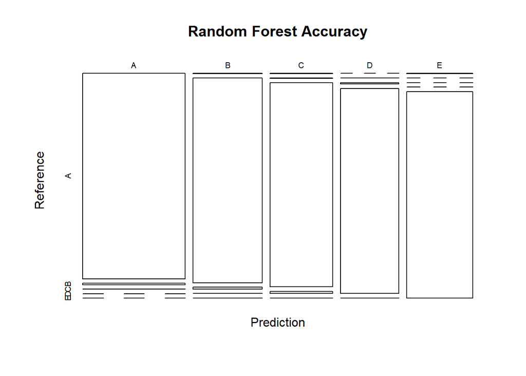

```r
plot(rf_cm$table, col=rf_cm$byClass, main="Random Forest Accuracy")
```

### Conclusion

The prediction accuracy for the Random Forest model is almost 99%. This is a very good model so we gonna use it for the test set prediction.

### Course Project Prediction Quiz

```r
test_pred <- predict(rf_model,test)
test_pred
```

```
##  [1] B A B A A E D B A A B C B A E E A B B B
## Levels: A B C D E
```